# White Wine Exploratory Data Analysis

## 4.5. Multivariate Analysis

**Talk about some of the relationships you observed in this part of the investigation. Were there features that strengthened each other in terms of looking at your feature(s) of interest?**

After layering on quality, I observed that wines with a moderate total sulfur dioxide content had better ratings. I also observed correlation between chlorides and residual sugar within wines that were rated the same quality. There was also a clear difference in correlation in citric and acetic acid content, between the poor and well-rated wines.

**Were there any interesting or surprising interactions between features?**

The most interesting interaction was the observed correlation between chlorides and residual sugar that popped up when the visualization was layered with quality ratings.

**Did you create any models with your dataset? Discuss the strengths and limitations of your model.**

I created a model with my dataset but it did not explain the main feature of interest- quality. The model had a R-squared value of 0.283 at best. It could be that quality rating was more subjective than thought or that a linear model was insufficient to describe the data. A polynomial non-linear model might fit the data better, considering that good wines typically have a moderate value of the various chemical properties.

# 5. Final Plots and Summary

## 5.1. Plot One

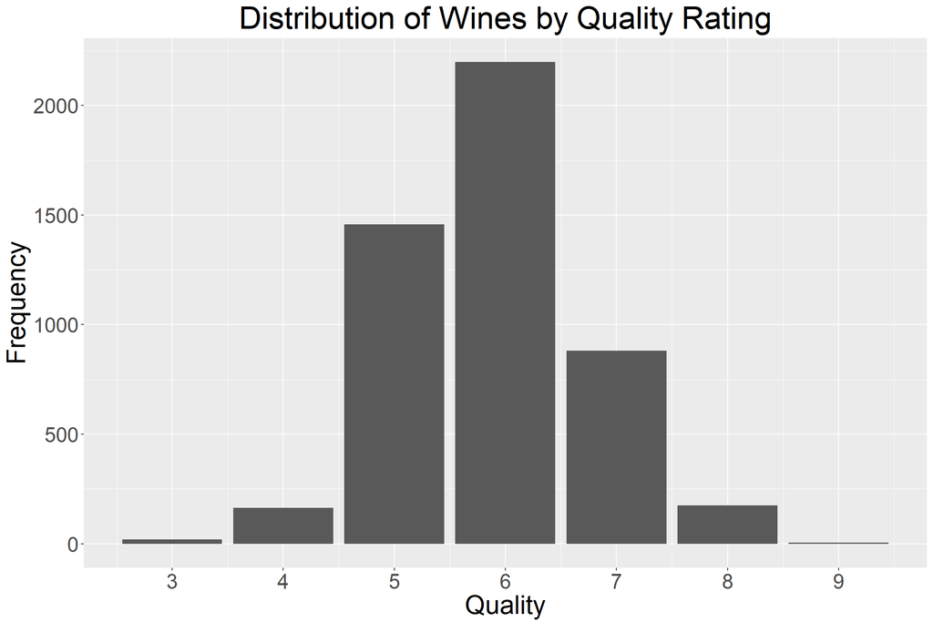

**Description** This is perhaps the most important univariate plot. It shows that ratings follows a normal distribution with most wines being rated average at 6, and that very bad or excellent wines are rare. The graph indicates that no winemaker sets out to produce very bad wines, and that while winemakers aim to make the most ideal wine, it is a difficult craft and they typically end up with an average wine.

## 5.2. Plot Two

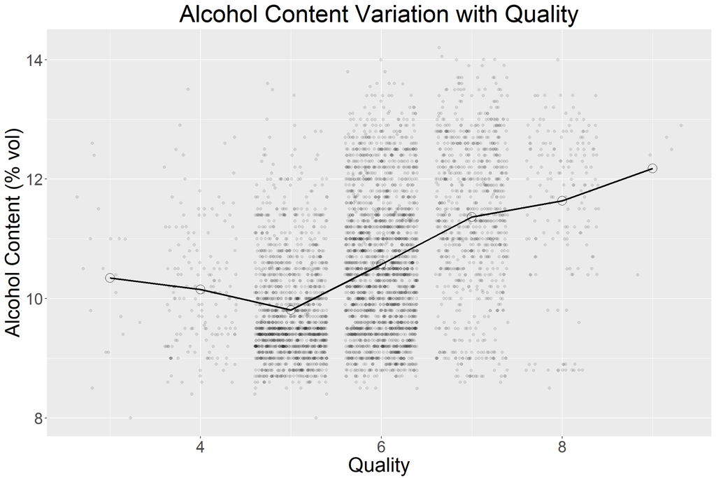

**Description** The chemical property that has the strongest correlation with wine quality is alcohol content. This bivariate analysis graph corroborates this and shows that wines with higher alcohol content gets rated higher.

## 5.3. Plot Three

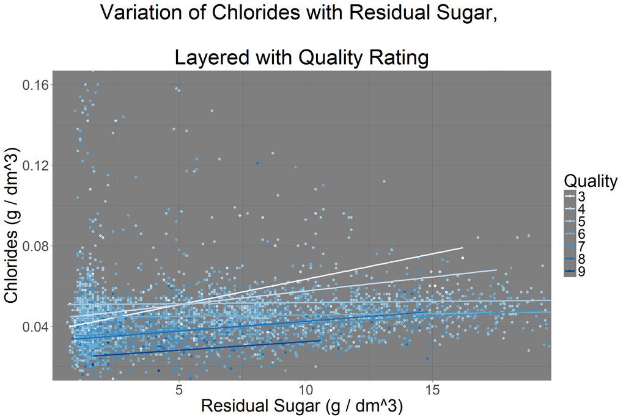

**Description** This plot shows that there is stronger correlation between chlorides and residual sugar if the dataset was split based on wine quality. This relationship would have been obscured from the scatterplot between chlorides and residual sugar for all data.

# 6. Reflection

**Insights found**

After performing the bivariate analysis, I realized that alot of the variables are related to one another. For example, pH is correlated to the acids, and residual sugar, density and alcohol content are also correlated. This means that the chemical properties could be grouped largely into

1. Acid Content (fixed acidity, volatile acidity, citric acid, pH)
2. Preservative Content (sulphates, total sulfur dioxide, free sulfur dioxide)
3. Salt Content (chlorides)
4. Alcohol Content (alcohol, residual sugar, density)

My conclusion is that wine quality was most influenced by alcohol content, and wines with higher alcohol content are rated higher.

It was surprising to find relationships that were obscured when the entire dataset was taken in its entirety, particularly for the correlation between chlorides and sugars.

**Difficulties encountered**

There were 11 chemical properties, the univariate and bivariate analyses of all the chemical properties means that many graphs were plotted. It was also difficult to decide on the combination of multivariate plots to create and I decided to investigate variables that had a clear taste effect (e.g. salty, sweet, vinegary and fruity).

**Future Work**

I built a linear model but it did not capture the characteristics of the dataset. I would extend this work by exploring non-linear models and also testing the subjectivity of various expert raters.